# Introduction

In the following \(\mathbf{X}\in\mathbb{R}^{n\times p}\) is a matrix of \(n\) rows and \(p\) columns describing the covariate part of a data set in a mono-block context. If this is a multi-block analysis, with one block for **Proteomics**, one block for **DNA methylation** for example and other \(K-2\) blocks, then the covariate data set is built on \(K\) blocks and is denoted as \[ \mathbf{X}_s=\{\mathbf{X}_{proteo},\mathbf{X}_{DNA},\cdots\}\in \mathbb{R}^{n\times p_{proteo}}\times\mathbb{R}^{n\times p_{DNA}}\times\cdots \] \(\mathbf{X}_s\) is treated with *list()* structure by the package, so in case of multi-block analysis, thanks to present your dataset such as

```r
# For no named matrices
Xs <- list(X1,X2,X3)

# For names matrices
Xs <- list(X_dna=X1,X_proteo=X2,X_RNA=X3)
```

if the covariate part is filled with only one data set, it is possible to use the *list()* structure or not.

In the other cases, the number of variables in each matrix can be different. In the previous examples we have denoted by \(p_{proteo}\) and \(p_{DNA}\) two of the different number of variables. It is knowd that **Proteomics** data-sets are filled with hundreds of variables while **DNA methylation** data sets gather hundreds of thousands of variables.

The supervizion part is described by the \(\mathbf{Y}\in\mathbb{R}^{n\times q}\) matrix. In case of regression it can be a *vector* for univariate case (\(q=1\)) or a *matrix* or even a *data.frame*. In multi-variate regression, \(q>1\), it can be a *matrix* or a *data.frame*. In case on classification, \(\mathbf{Y}\) must be unidimensionnal but it can be a *vector* or a *matrix* or even a *data.frame*. The argument *mode* permits to choose between regression mode, then use *reg*, and classification mode, then use something else.

In the \(\mathbf{X}_s\) and \(\mathbf{Y}\) data sets, the same numbers of individuals are described, \(n\) and each of them are on the same row

**No individual can be missing in all the \(\mathbf{X}\) matrices and no missing entry is allowed in the \(\mathbf{Y}\) dataset**.

# Introduction

The present package is based on [@lorenzo2019supervised]. It permits to take into account missing values in a multi-block context for supervized problems. It also permits to deal with data analyses with no missing values. Regression or classification regression paradigms are accepted.

Only two parameters must to be fixed by the user :

- **R** which is the number of components, analogous to the number of components in PCA.
- **\(\lambda\)** which is the regularization coefficient, \(\lambda\in[0,1]\). It can be directly interpreted as the minimum of correlation value under which an interaction between a variable of a block \(\mathbf{X}\) and one of the \(\mathbf{Y}\) variables is not taken into account.

Those two parameters are to be fixed with cross validation. We have developped a parallelizable code, using **doParallel** package, see [@doparalelManual]. This is transparent for the user, which hase just to fix the number of *cpus* to be used. The corresponding parameter is denoted as **NCORES**. If it equals \(1\), then no parallelization structure is deployed.

To load the **ddsPLS** package:

```r
library(ddsPLS)
```

In the following, only **regression** examples are shown. To perform classification analyses, please change the argument

```r
mode
```

in any of the functions to something different from **“reg”**. In the example

```r
data("penicilliumYES")
X <- penicilliumYES$X
X <- scale(X[,which(apply(X,2,sd)>0)])
Xs <- list(X[,1:1000],X[,-(1:1000)])
Xs[[1]][1:5,]=Xs[[2]][6:10,] <- NA
Y <- as.factor(unlist(lapply(c("Melanoconidiu","Polonicum","Venetum"),function(tt){rep(tt,12)})))

mddsPLS_model_class <- mddsPLS(Xs = Xs,Y = Y,L0=3,R = 2,mode = "clas",verbose = TRUE)
```

is considered a mult-block classification case analysis with missing samples.

# Mono-block

The here used method can be used on mono and multi-block datasets with no missing values. In the case on mono-block datasets, there is no current developpment to deal with missing samples. Actually this would imply that for a given individual, no covariate is known. Which block any inference.

## Regression case {.tabset}

The regression case has been treated through a toy example well know dataset in that section.

### Build a model {.tabset}

We have worked on the Liver Toxicity dataset, see @bushel2007simultaneous. This data set contains the expression measure of 3116 genes and 10 clinical measurements for 64 subjects (rats) that were exposed to non-toxic, moderately toxic or severely toxic doses of acetaminophen in a controlled experiment. Therefore the structure is : \[\mathbf{X}\in\mathbb{R}^{64\times3116},\mathbf{Y}\in\mathbb{R}^{64\times10}\]

The following commands permit to create the model. The parameter *verbose* shows main information about the model.

```r
data("liver.toxicity")
X <- scale(liver.toxicity$gene)
Y <- scale(liver.toxicity$clinic)
mddsPLS_model_reg <- mddsPLS(Xs = X,Y = Y,lambda=0.85,R = 3,
                             mode = "reg",verbose = TRUE)
```

```
## At most 15 variable(s) can be selected in the X part
##     For each block of X, are selected in order of component:
##         @ (14,1,14) variable(s)
##     For the Y block, are selected in order of component:
##         @ (2,2,1) variable(s)
```

#### Plot Method {.tabset}

The **Plot** mehtod permits many types of representation. Among which

- *weights* which shows all the weights under barplot representations. If **super** is set to **TRUE**, then the **super-weights** are represented. In the mono-block case, **super-weights** are equal to **weights**.
- *heatmap* which shows the selected variables (for \(\mathbf{X}\) and \(\mathbf{Y}\)) for the all individuals.

The following sections detailed the discussed method though those parametizations.

##### *Super-Weight* representation

The following figure permits to represent the *super-weights* for the first and the second components for block 1 (mono-block case actually) and block Y. **mar_left** parameter adds extra values on the left of the plot, usefull to see variable names.

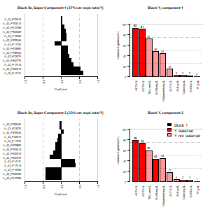

```r
plot(mddsPLS_model_reg,vizu = "weights",variance = "Linear",
     super = T,comp = c(1,2),addY = T,mar_left = 3,mar_bottom = 3,
     pos_legend = "topright",reorder_Y = T,legend.cex = 1.5)
```

##### *Heatmap* representation

Heatmap permit to appreciate the discriminative aspect of variables according to their individual representations. It has been decided to plot heatmaps component per component, only the first one here

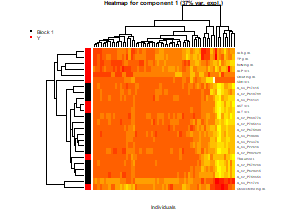

```r
plot(mddsPLS_model_reg,vizu = "heatmap",comp = 1)
```

Each variable has been normalized separately. Dendrogram are used in the individual and in the variable directions using **hclust** similarities.

#### Summary Method

A *summary* method explains more precisely the model.

```r
summary(mddsPLS_model_reg)
```

```
## ===============================================================
##                      ddsPLS object description
## ===============================================================
##
## Number of blocks: 1
## Number of dimensions: 3
## Regularization coefficient: 0.85
## Number of individuals: 64
## Number of variables in Y part: 10
## Model built in mode regression
## Maximum number of iterations in the imputation process: 50
## Algorithm of imputation has converged
##
##
##           Variance Explained (%)
## -------------------------------------------
## Total Y variance explained by each Super Component
## [1] 37 33 29
##
## Marginal Y variable variance explained by each Super Component
##                    Super Comp. 1 Super Comp. 2 Super Comp. 3
## BUN.mg.dL.                48.000         43.00         29.00
## Creat.mg.dL.               2.200          3.30          0.82
## TP.g.dL.                   0.088          0.84          2.20
## ALB.g.dL.                  2.500          3.90          0.58
## ALT.IU.L.                 92.000         79.00         71.00
## SDH.IU.L.                  1.900          3.30          6.00
## AST.IU.L.                 91.000         74.00         69.00
## ALP.IU.L.                 15.000         17.00         11.00
## TBA.umol.L.               72.000         59.00         81.00
## Cholesterol.mg.dL.        44.000         45.00         21.00
##
## Total Y variance explained by each component of each block
##         Comp. 1 Comp. 2 Comp. 3
## Block 1      37      29      33
##
##
##           Variance In Common (%) (RV coefficient)
## -------------------------------------------------------
## Total Y variance in common with each Super Component
```

[output cut: 30 more lines]

```
## -------------------------------------------
##
## At most 15 variable(s) can be selected in the X part
##     For each block of X, are selected
##   Super Comp. 1 Super Comp. 2 Super Comp. 3
## 1            14            14             1
##     For the Y block, are selected
##         @ (2,2,1) variable(s)
##
##
##                  Thank's for using me
## ---------------------------------------------------------------
##                                                 Hadrien Lorenzo
##                                  hadrien.lorenzo.2015@gmail.com
## ===============================================================
```

#### Get selected variables

Output *var_selected* permits to get the selected variables per block.

```r
mddsPLS_model_reg$var_selected[[1]]
```

```
##              Weights_comp_1 Weights_comp_2 Weights_comp_3
## A_42_P809565     0.00000000              1     0.00000000
## A_43_P14131     -0.59972998              0     0.35720155
## A_43_P17415     -0.33110866              0     0.38407399
## A_42_P610788    -0.07179133              0    -0.42664976
## A_42_P620915    -0.51494107              0    -0.20152716
## A_42_P802628    -0.11713487              0    -0.41810461
## A_43_P10606     -0.14029029              0    -0.41477415
## A_43_P11724      0.17176035              0    -0.09521232
## A_42_P578246    -0.14279939              0     0.05666098
## A_43_P23376     -0.21321205              0    -0.03919097
## A_42_P758454    -0.17533343              0    -0.03346941
## A_42_P705413    -0.02559837              0    -0.14711216
## A_43_P22616     -0.01249312              0    -0.07424555
## A_42_P840776    -0.26355093              0    -0.30453411
## A_42_P675890    -0.17494527              0    -0.14343829
##              Super_Weights_comp_1 Super_Weights_comp_2
## A_42_P809565           0.00000000           0.00000000
## A_43_P14131            0.59972998           0.35720155
## A_43_P17415            0.33110866           0.38407399
## A_42_P610788           0.07179133          -0.42664976
## A_42_P620915           0.51494107          -0.20152716
## A_42_P802628           0.11713487          -0.41810461
## A_43_P10606            0.14029029          -0.41477415
## A_43_P11724           -0.17176035          -0.09521232
## A_42_P578246           0.14279939           0.05666098
## A_43_P23376            0.21321205          -0.03919097
## A_42_P758454           0.17533343          -0.03346941
## A_42_P705413           0.02559837          -0.14711216
## A_43_P22616            0.01249312          -0.07424555
## A_42_P840776           0.26355093          -0.30453411
## A_42_P675890           0.17494527          -0.14343829
##              Super_Weights_comp_3
## A_42_P809565                    1
## A_43_P14131                     0
## A_43_P17415                     0
## A_42_P610788                    0
## A_42_P620915                    0
## A_42_P802628                    0
## A_43_P10606                     0
## A_43_P11724                     0
## A_42_P578246                    0
## A_43_P23376                     0
## A_42_P758454                    0
## A_42_P705413                    0
## A_43_P22616                     0
## A_42_P840776                    0
## A_42_P675890                    0
```

### Cross Validation {.tabset}

The cross-validation process is started in a leave-one-out design along \(1\) dimension. **NCORES** fixes the number of cores in the paralellized process, **n_lambda** fixes the number of regularization coefficients to be tested.

```r
n_lambda <- 50
NCORES <- 7
res_cv_reg <- perf_mddsPLS(Xs = X,Y = Y,
                           R = 1,lambda_min=0.5,n_lambda=n_lambda,
                           mode = "reg",NCORES = NCORES,kfolds = "loo")

res_cv_reg_L0 <- perf_mddsPLS(Xs = X,Y = Y,
                           R = 1,L0s=1:50,
                           mode = "reg",NCORES = NCORES,kfolds = "loo")
```

#### Error Plot {.tabset}

A *plot* method plots the results. *plot_mean* permits to add the mean of the **Y** variable prediction errors. *legend_names* permits to add a legend with the names of the **Y** variables. *pos_legend* permits to choose the position of the legend. *which_sd_plot* picks the **Y** variables whose standard error must be drawn.

##### Using \(\lambda\) paradigm

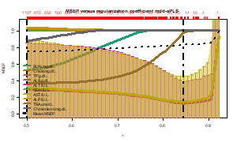

```r
plot(res_cv_reg,which_sd_plot = c(5,7),ylim=c(0,1.1),
     alpha.f = 0.4,plot_mean = T,legend_names = colnames(Y),
     no_occurence = T)
```

Minimum for \(\lambda\approx0.85\).

##### Using \(L_0\) paradigm

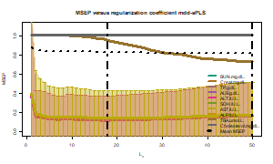

```r
plot(res_cv_reg_L0,which_sd_plot = c(5,7),ylim=c(0,1.1),alpha.f = 0.4,
     plot_mean = T,legend_names = colnames(Y),pos_legend = "bottomright",no_occurence = T)
```

Minimum for \(L_0\approx 18\).

##### Observations

Are also plotted vertical lines representing:

- The global minimum,
- The minimum of the **Mean MSEP**.

The two panels building this plot are headed with numbers. Red for the error curves and blue for the \(\mathbf{Y}\) variable occurence curves. It represents the number of variables selected in the \(\mathbf{X}\) and in the \(\mathbf{Y}\) respectively for the model built on the matrices given to the function.

If one would not prefer to see the occurence plot. The parameter *no_occurence*, when set to **TRUE**, permits to hide it.

#### Summary Method

A *summary* methods explains more precisely the model. The parameter *plot_res_cv* uses the **plot** method. Are also presented the statistical results of the algorithm (convergence for each fold, time of computation).

```r
summary(res_cv_reg,plot_res_cv =F)
```

```
## ======================================================
##       Cross-Validation ddsPLS object description
## ======================================================
##
## Number of blocks: 1
## Number of individuals: 64
## Number of variables in Y part: 0
## Model built in mode regression
##
##
##     Missing value information
## ---------------------------------
##
##                                     X1 Total
## Number of variables               3116  3116
```

[output cut: 116 more lines]

The **Cross-Validation results** is a matrix with **4** columns and **N** rows, each row corresponds to a couple \((R,\lambda)\) teste. Each column correpsonds to:

- **R**: The number of components built,
- **lambda**: The regularization coefficient,
- **Nb.of.convergences.VS.nb.of.fold**: The number of models, in the cross-validation process, which have converged against the total number of models built.
- **Mean.sd..time.of.computation**: The mean time of computation for bulding a model and, in parenthesis, its standard deviation.

# Multi-block

Two different analyses are detailed here, the first one presents the tool and the second one permits to simulate a data-set and details its analysis thanks to the **ddsPLS** tool.

## Toy example {.tabset}

In the case of missing values it is possible to visualize the missing positions. Let us just consider a 3-blocks toy-example case, based on the previous dataset, such as

```r
data("liver.toxicity")
X <- scale(liver.toxicity$gene)
Y <- scale(liver.toxicity$clinic)
p1=p2 <- 1000
p3 <- ncol(X)-p1-p2
Xs <- list(Block1=X[,1:p1],Matrix2=X[,p1+1:p2],Other_Variables=X[,p1+p2+1:p3])
Xs$Block1[1:10,] <- NA
Xs$Matrix2[5+1:10,] <- NA
Xs$Other_Variables[10+1:20,] <- NA

model_multi_vizu <- mddsPLS(Xs,Y,lambda = 0.8,R = 3)
```

### Plot Method {.tabset}

The **Plot** mehtod permits many types of representation. Among which

- *weights* which shows all the weights under barplot representations. If **super** is set to **TRUE**, then the **super-weights** are represented. In the mono-block case, **super-weights** are equal to **weights**.
- *heatmap* which shows the selected variables (for \(\mathbf{X}\) and \(\mathbf{Y}\)) for the all individuals.

The following sections detailed the discussed method though those parametizations.

#### *Scaled Super-Weight* representation {.tabset}

The following figure permits to represent the *scaled super-weights* for blocks 1, 2 and block Y. **mar_left** parameter adds extra values on the left of the plot, usefull to see variable names. Only the first cuper-component is plotted.

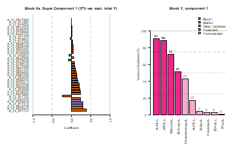

```r
plot(model_multi_vizu,vizu = "weights",super = T,comp=1 ,addY = T,
     mar_left = 5,mar_bottom = 3,reorder_Y = T)
```

#### *Heatmap* representation {.tabset}

Heatmap permit to appreciate the discriminative aspect of variables according to their individual representations. It has been decided to plot heatmaps component per component, only the first component in the case of that example.

Each variable has been normalized separately. Dendrogram are used in the individual and in the variable directions using **hclust** similarities.

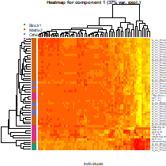

```r
plot(model_multi_vizu,vizu = "heatmap",comp = 1)
```

### Summary Method

A *summary* method explains more precisely the model.

```r
summary(model_multi_vizu)
```

```
## ===============================================================
##                      ddsPLS object description
## ===============================================================
##
## Number of blocks: 3
## Number of dimensions: 3
## Regularization coefficient: 0.8
## Number of individuals: 64
## Number of variables in Y part: 10
## Model built in mode regression
## Maximum number of iterations in the imputation process: 50
## Algorithm of imputation has converged
##
##
##           Variance Explained (%)
## -------------------------------------------
## Total Y variance explained by each Super Component
## [1] 37 31 30
##
## Marginal Y variable variance explained by each Super Component
##                    Super Comp. 1 Super Comp. 2 Super Comp. 3
## BUN.mg.dL.                 51.00          50.0          49.0
## Creat.mg.dL.                3.00           2.5           5.1
## TP.g.dL.                    0.47           1.1           3.9
## ALB.g.dL.                   3.90           5.4          10.0
## ALT.IU.L.                  91.00          70.0          68.0
## SDH.IU.L.                   2.50           1.6           2.3
## AST.IU.L.                  89.00          70.0          61.0
## ALP.IU.L.                  17.00          21.0          18.0
## TBA.umol.L.                72.00          56.0          49.0
## Cholesterol.mg.dL.         43.00          35.0          36.0
##
## Total Y variance explained by each component of each block
##                 Comp. 1 Comp. 2 Comp. 3
## Block1               32    21.0      19
## Matrix2              37    24.0      31
## Other_Variables      37     9.5      26
##
##
##           Variance In Common (%) (RV coefficient)
```

[output cut: 36 more lines]

```
## At most 39 variable(s) can be selected in the X part
##     For each block of X, are selected
##                 Super Comp. 1 Super Comp. 2 Super Comp. 3
## Block1                      3             3             3
## Matrix2                    29            28            29
## Other_Variables             7             7             7
##     For the Y block, are selected
##         @ (4,3,4) variable(s)
##
##
##                  Thank's for using me
## ---------------------------------------------------------------
##                                                 Hadrien Lorenzo
##                                  hadrien.lorenzo.2015@gmail.com
## ===============================================================
```

### Get selected variables

Output *var_selected* permits to get the selected varaibles per block.

Here is represented its value for the first block

```r
model_multi_vizu$var_selected[[1]]
```

```
##              Weights_comp_1 Weights_comp_2 Weights_comp_3
## A_43_P18824       0.2021202      0.3106499     0.92878632
## A_43_P16842       0.8112084     -0.5844501     0.01894704
## A_42_P470649      0.5487152      0.7496097    -0.37013102
##              Super_Weights_comp_1 Super_Weights_comp_2
## A_43_P18824           -0.02591159           -0.3312496
## A_43_P16842           -0.05547870           -0.4429440
## A_42_P470649          -0.07391688           -0.2621193
##              Super_Weights_comp_3
## A_43_P18824           -0.21819422
## A_43_P16842           -0.03013106
## A_42_P470649           0.02654694
```